# Lab 1: CNN Visualization

Yasmin Femerling, Alejandro de Leon

February 24, 2021

*Neural Networks and Machine Learning*

## VGG

VGG is a convolutional neural network which is primarily focused on large-scale image recognition. This architecture was used to win ILSVR (ImageNet) competition in 2014, achieving 92.7% top-5 test accuracy in ImageNet. It is one of the most widely used CNN and very simple to implement, so it is highly documented and analyzed online. It is sometimes considered a building block for educational purposes due to its ease of use. This is one of the reasons that this CNN was chosen.

Among the analyses online that is available about it is the OpenAI Microscope feature visualization. This allows us to look through the layers and channels of the network and made it easy to select a filter to use in this lab. Another important reason could be that any doubt about the structure or characteristics of the network could be easily answered through an online search. Finally, this is a simple network to analyze since it has a simple architecture and doesn't include complex feed forward operations that could make the analysis of the excitations and inhibitions of filters difficult. [1]

## Setup and Loading Model

```python
# Setup and Keras importation

import numpy as np
import tensorflow as tf
import matplotlib.pyplot as plt
from PIL import Image
from tensorflow.keras.applications.vgg19 import VGG19
from tensorflow.keras.preprocessing import image
from tensorflow.keras.applications.vgg19 import preprocess_input, decode_predictions
from tensorflow.keras.models import Model
```

```python
# Loading and testing VGG19 Model
# Simple setup for testing

model = VGG19(
    include_top=True,
    weights="imagenet",
    input_tensor=None,
    input_shape=None,
    pooling=None,
    classes=1000,
    classifier_activation="softmax",
    )
```

## Simple Image Classification

The next section shows the test images that will be classified by the VGG19. A dog, a car and a lampshade where chosen. The purpose of this is to ensure that VGG19 makes the correct predictions.

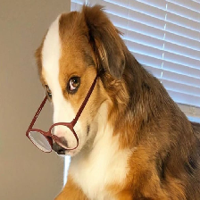

[figure not shown]

[figure not shown]

```python
# Loading images and displaying

imgPaths = ['test1.jpg', 'test2.jpg', 'test3.jpg']
imgs = []

for path in imgPaths:
    imgs.append(image.load_img(path, target_size = (224, 224)))

display(imgs[0])
display(imgs[1])
display(imgs[2])
```

```python
# Stacking images to send in single batch
images_array = imgs;
result = np.stack((images_array[0], images_array[1], images_array[2]))

# Preprocessing images for VGG19
result = preprocess_input(result)
```

```python
# Model predictions
preds = model.predict(result)
print('Predicted: ', decode_predictions(preds, top=1)[0:3])
```

```
Predicted:  [[('n02113023', 'Pembroke', 0.4595377)], [('n04037443', 'racer', 0.3920903)], [('n04380533', 'table_lamp', 0.6340781)]]
```

**The prediction results are the following:**

- Test 1 **Pembroke** with 45.95% probability (*Pembroke is a dog breed*)
- Test 2 **Racer** with 39.21% probability
- Test 3 **Table** Lamp with 63.41% probability

## Feature Selection

We have chosen the channel 196 from the block 4 and convolutional layer 3. We will analyse the activation from this layer.

```python
# Model summary
model.summary()
```

```
Model: "vgg19"
_________________________________________________________________
Layer (type)                 Output Shape              Param #
=================================================================
input_1 (InputLayer)         [(None, 224, 224, 3)]     0
_________________________________________________________________
block1_conv1 (Conv2D)        (None, 224, 224, 64)      1792
_________________________________________________________________
block1_conv2 (Conv2D)        (None, 224, 224, 64)      36928
_________________________________________________________________
block1_pool (MaxPooling2D)   (None, 112, 112, 64)      0
_________________________________________________________________
block2_conv1 (Conv2D)        (None, 112, 112, 128)     73856
_________________________________________________________________
block2_conv2 (Conv2D)        (None, 112, 112, 128)     147584
_________________________________________________________________
block2_pool (MaxPooling2D)   (None, 56, 56, 128)       0
_________________________________________________________________
block3_conv1 (Conv2D)        (None, 56, 56, 256)       295168
_________________________________________________________________
block3_conv2 (Conv2D)        (None, 56, 56, 256)       590080
_________________________________________________________________
block3_conv3 (Conv2D)        (None, 56, 56, 256)       590080
_________________________________________________________________
block3_conv4 (Conv2D)        (None, 56, 56, 256)       590080
_________________________________________________________________
block3_pool (MaxPooling2D)   (None, 28, 28, 256)       0
_________________________________________________________________
block4_conv1 (Conv2D)        (None, 28, 28, 512)       1180160
_________________________________________________________________
block4_conv2 (Conv2D)        (None, 28, 28, 512)       2359808
_________________________________________________________________
block4_conv3 (Conv2D)        (None, 28, 28, 512)       2359808
_________________________________________________________________
block4_conv4 (Conv2D)        (None, 28, 28, 512)       2359808
_________________________________________________________________
block4_pool (MaxPooling2D)   (None, 14, 14, 512)       0
_________________________________________________________________
block5_conv1 (Conv2D)        (None, 14, 14, 512)       2359808
_________________________________________________________________
block5_conv2 (Conv2D)        (None, 14, 14, 512)       2359808
_________________________________________________________________
block5_conv3 (Conv2D)        (None, 14, 14, 512)       2359808
_________________________________________________________________
block5_conv4 (Conv2D)        (None, 14, 14, 512)       2359808
_________________________________________________________________
block5_pool (MaxPooling2D)   (None, 7, 7, 512)         0
_________________________________________________________________
flatten (Flatten)            (None, 25088)             0
_________________________________________________________________
fc1 (Dense)                  (None, 4096)              102764544
_________________________________________________________________
fc2 (Dense)                  (None, 4096)              16781312
_________________________________________________________________
predictions (Dense)          (None, 1000)              4097000
=================================================================
Total params: 143,667,240
Trainable params: 143,667,240
Non-trainable params: 0
_________________________________________________________________
```

```python
# Layer selection, the output will be from the block4_conv3 convolutional layer
layerModel = Model(inputs = model.input, outputs = model.get_layer('block4_conv3').output)
block4_conv3_features = layerModel.predict(result)
```

We test the activation layer with the images used in the simple classification section (dog, car, lamp).

```
(-0.5, 27.5, 27.5, -0.5)
```

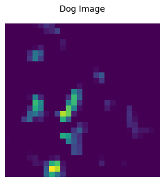

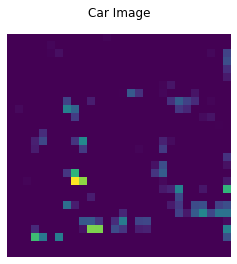

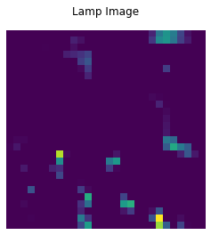

```python
# Visualization of the excitation for the test images

plt.matshow(block4_conv3_features[0,:,:,196])
plt.title('Dog Image')
plt.axis('off')
plt.matshow(block4_conv3_features[1,:,:,196])
plt.title('Car Image')
plt.axis('off')
plt.matshow(block4_conv3_features[2,:,:,196])
plt.title('Lamp Image')
plt.axis('off')
```

The results show sections in yellow (high excitation) and green (medium excitation) that activated the filter. To understand what is happening further analysis from the filter is needed. Gradient descent will be used to visualize what could maximally excite the filter and check why those sections from the above image are highlighted.

Some assumptions can be taken from these: On the results of the Dog Image, the filter is excited by the round edges of the dog's glasses and part of the fur's color. On the results of the Car Image, the filter is excited by the edges of the wheels and the structure of the car, which are all round borders. On the results of the Lamp Image, the filter is excited by the edges of the books and the base of the lamp and by the head of the horse figure.